# TUGAS AKHIR PRAK TPG

Irsyad Fariz Sena Pratama

2025-12-16

Analisis ini bertujuan untuk mengetahui hubungan simultan antara faktor psikologis mahasiswa yang terdiri dari locus of control, konsep diri, dan motivasi dengan kemampuan akademik yang direpresentasikan oleh variabel kemampuan membaca dan variabel akademik lainnya. Metode yang digunakan adalah Analisis Korelasi Kanonik (Canonical Correlation Analysis/CCA), karena metode ini sesuai untuk mengkaji hubungan antara dua set variabel numerik secara bersama-sama.

# BAGIAN 1: PERSIAPAN LINGKUNGAN KERJA & LIBRARY

```r
# Install paket jika belum ada
list.of.packages <- c("CCA", "CCP", "ggplot2", "GGally", "psych", "dplyr", "tidyr")
new.packages <- list.of.packages[!(list.of.packages %in% installed.packages()[,"Package"])]
if(length(new.packages)) install.packages(new.packages)

# Load Library
library(CCA)      # Core library untuk CCA
library(CCP)      # Untuk uji signifikansi (Wilks)
library(ggplot2)  # Visualisasi modern
library(GGally)   # Visualisasi korelasi matrix
library(psych)    # Statistik deskriptif
library(dplyr)    # Manipulasi data
library(tidyr)    # Merapikan data
```

# BAGIAN 2: LOAD & PRE-PROCESSING DATA

```r
# 1. Import Data CSV
dataku <- read.csv("C:/Users/01-USER/Downloads/mmreg.csv")

# Mengganti nama kolom agar lebih mudah dipahami
colnames(dataku) <- c("Locus_Control", "Konsep_Diri", "Motivasi",
                  "Baca", "Tulis", "Matematika", "Sains", "Gender")

# Memisahkan Variabel X (Psikologis) dan Y (Akademik)
# Kita membuang 'Gender' karena CCA standar butuh variabel kontinu
X <- dataku[, c("Locus_Control", "Konsep_Diri", "Motivasi")]
Y <- dataku[, c("Baca", "Tulis", "Matematika", "Sains")]

# Standarisasi Data (PENTING untuk insight perbandingan koefisien)
X_scale <- scale(X)
Y_scale <- scale(Y)

# Cek apakah data berhasil masuk
print(head(dataku))
```

```
##   Locus_Control Konsep_Diri Motivasi Baca Tulis Matematika Sains Gender
## 1         -0.84       -0.24     1.00 54.8  64.5       44.5  52.6      1
## 2         -0.38       -0.47     0.67 62.7  43.7       44.7  52.6      1
## 3          0.89        0.59     0.67 60.6  56.7       70.5  58.0      0
## 4          0.71        0.28     0.67 62.7  56.7       54.7  58.0      0
## 5         -0.64        0.03     1.00 41.6  46.3       38.4  36.3      1
## 6          1.11        0.90     0.33 62.7  64.5       61.4  58.0      1
```

```r
print(names(dataku)) # Lihat nama-nama kolom untuk menentukan X dan Y
```

```
## [1] "Locus_Control" "Konsep_Diri"   "Motivasi"      "Baca"
## [5] "Tulis"         "Matematika"    "Sains"         "Gender"
```

```r
# 2. Membersihkan Data (PENTING)
# Hapus baris yang kosong (NA) jika ada, agar tidak error saat perhitungan
dataku <- na.omit(dataku)
```

# BAGIAN 3: EKSPLORASI DATA (EDA) - “Insight Awal”

```r
cat("\n--- Statistik Deskriptif Variabel X (Psikologis) ---\n")
```

```
##
## --- Statistik Deskriptif Variabel X (Psikologis) ---
```

```r
print(describe(X))
```

```
##               vars   n mean   sd median trimmed  mad   min  max range  skew
## Locus_Control    1 600 0.10 0.67   0.21    0.14 0.62 -2.23 1.36  3.59 -0.61
## Konsep_Diri      2 600 0.00 0.71   0.03    0.06 0.52 -2.62 1.19  3.81 -0.89
## Motivasi         3 600 0.66 0.34   0.67    0.70 0.49  0.00 1.00  1.00 -0.59
##               kurtosis   se
## Locus_Control     0.31 0.03
## Konsep_Diri       1.52 0.03
## Motivasi         -0.89 0.01
```

```r
cat("\n--- Statistik Deskriptif Variabel Y (Akademik) ---\n")
```

```
##
## --- Statistik Deskriptif Variabel Y (Akademik) ---
```

```r
print(describe(Y))
```

```
##            vars   n  mean    sd median trimmed   mad  min  max range  skew
## Baca          1 600 51.90 10.10   52.1   51.76 11.71 28.3 76.0  47.7  0.13
## Tulis         2 600 52.38  9.73   54.1   52.99 11.56 25.5 67.1  41.6 -0.47
## Matematika    3 600 51.85  9.41   51.3   51.52 10.16 31.8 75.5  43.7  0.26
## Sains         4 600 51.76  9.71   52.6   51.93 12.01 26.0 74.2  48.2 -0.16
##            kurtosis   se
## Baca          -0.77 0.41
## Tulis         -0.71 0.40
## Matematika    -0.65 0.38
## Sains         -0.70 0.40
```

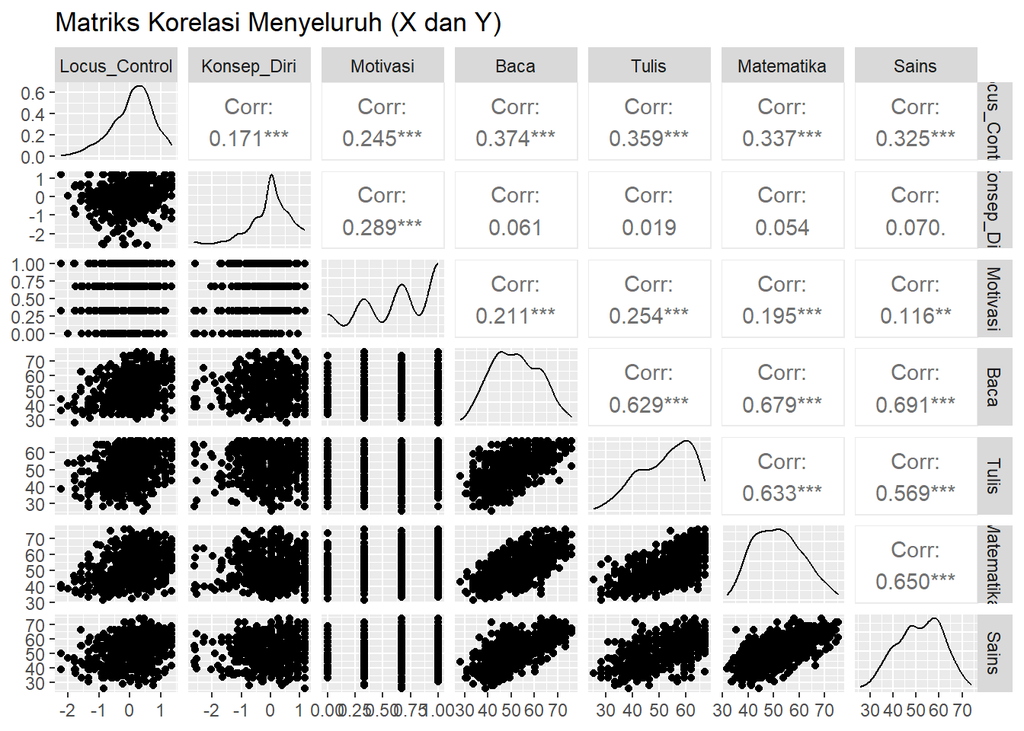

```r
# Visualisasi Korelasi Antar Variabel (Dalam Grup dan Antar Grup)
# Ini penting untuk melihat multikolinearitas dan hubungan awal
ggpairs(data.frame(X, Y),
        title = "Matriks Korelasi Menyeluruh (X dan Y)")
```

Matriks korelasi menunjukkan bahwa variabel psikologis memiliki hubungan positif dengan kemampuan akademik, meskipun kekuatannya bervariasi. Locus of control dan motivasi memiliki korelasi positif dan signifikan dengan seluruh variabel akademik, dengan kekuatan hubungan lemah hingga sedang, yang mengindikasikan bahwa semakin baik kontrol diri dan motivasi individu, cenderung semakin baik pula kemampuan akademiknya. Sebaliknya, konsep diri menunjukkan korelasi yang sangat lemah dan sebagian besar tidak signifikan dengan variabel akademik, sehingga secara langsung perannya tidak terlalu menonjol.

Di sisi lain, hubungan antarvariabel akademik seperti membaca, menulis, matematika, dan sains terlihat sangat kuat dan signifikan. Hal ini menunjukkan bahwa kemampuan akademik saling berkaitan erat dan kemungkinan merepresentasikan satu konstruk kemampuan akademik umum. Secara keseluruhan, matriks korelasi ini mendukung bahwa faktor psikologis—terutama locus of control dan motivasi—berkaitan dengan kemampuan akademik, serta menguatkan penggunaan Analisis Korelasi Kanonik untuk melihat hubungan kedua set variabel secara simultan.

# BAGIAN 4: EKSEKUSI CCA

```r
# Menjalankan CCA pada data yang sudah distandarisasi
cca_fit <- cc(X_scale, Y_scale)

# 1. Canonical Correlations (Seberapa kuat hubungan antar set?)
cat("\n--- Korelasi Kanonik (Canonical Correlations) ---\n")
```

```
##
## --- Korelasi Kanonik (Canonical Correlations) ---
```

```r
print(cca_fit$cor)
```

```
## [1] 0.44643648 0.15335902 0.02250348
```

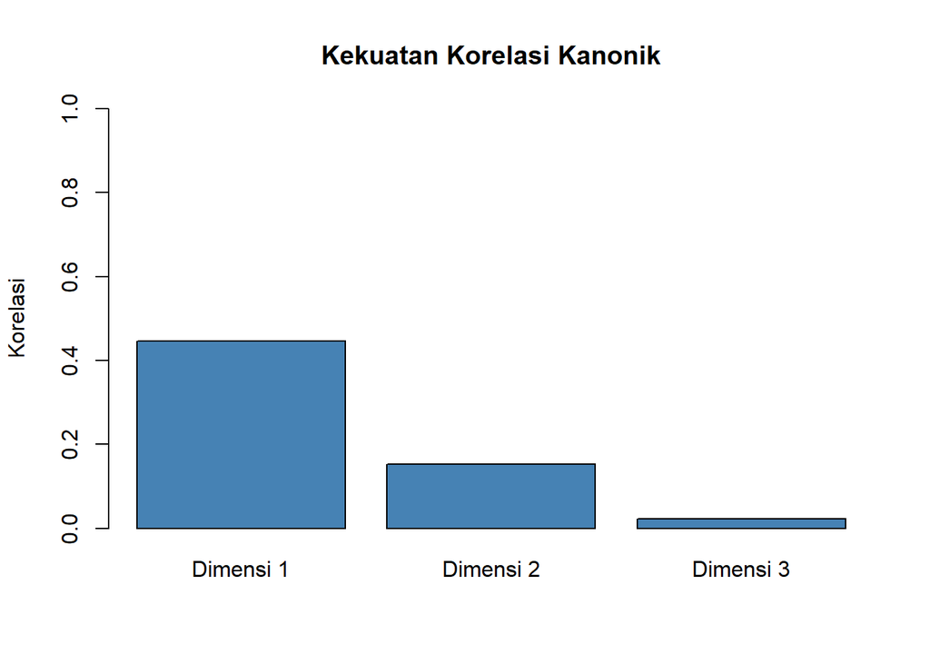

```r
# Visualisasi Kekuatan Korelasi Kanonik (Scree Plot)
barplot(cca_fit$cor, main = "Kekuatan Korelasi Kanonik",
        names.arg = paste("Dimensi", 1:length(cca_fit$cor)),
        col = "steelblue", ylim = c(0, 1), ylab = "Korelasi")
```

Hasil analisis menunjukkan bahwa korelasi kanonik tertinggi terdapat pada dimensi pertama dengan nilai sekitar 0,45, yang mengindikasikan adanya hubungan sedang antara kombinasi variabel psikologis dan akademik. Dimensi kedua memiliki korelasi yang jauh lebih kecil, sedangkan dimensi ketiga hampir mendekati nol. Hal ini menunjukkan bahwa hubungan utama antara kedua set variabel sebagian besar dijelaskan oleh dimensi pertama, sementara dimensi berikutnya memberikan kontribusi yang relatif kecil.

# BAGIAN 5: INTERPRETASI MENDALAM (Insight Utama)

```r
# Hitung 'Loadings' (Korelasi antara variabel asli dengan variabel kanonik)
# Loadings lebih stabil untuk interpretasi daripada raw coefficients
loadings <- comput(X_scale, Y_scale, cca_fit)

# A. Canonical Loadings (Muatan Kanonik)
cat("\n--- Canonical Loadings X (Seberapa besar X membentuk Variabel Kanonik X) ---\n")
```

```
##
## --- Canonical Loadings X (Seberapa besar X membentuk Variabel Kanonik X) ---
```

```r
print(round(loadings$corr.X.xscores, 3))
```

```
##                 [,1]   [,2]   [,3]
## Locus_Control -0.914  0.394  0.095
## Konsep_Diri   -0.100  0.421 -0.901
## Motivasi      -0.585 -0.606 -0.539
```

```r
cat("\n--- Canonical Loadings Y (Seberapa besar Y membentuk Variabel Kanonik Y) ---\n")
```

```
##
## --- Canonical Loadings Y (Seberapa besar Y membentuk Variabel Kanonik Y) ---
```

```r
print(round(loadings$corr.Y.yscores, 3))
```

```
##              [,1]   [,2]   [,3]
## Baca       -0.880  0.245 -0.273
## Tulis      -0.910 -0.221  0.340
## Matematika -0.800  0.188 -0.284
## Sains      -0.694  0.676  0.238
```

```r
# B. Cross Loadings (Insight Silang)
# Korelasi variabel X dengan Variabel Kanonik Y (dan sebaliknya)
cat("\n--- Cross Loadings (Hubungan Variabel Asli X dengan Kanonik Y) ---\n")
```

```
##
## --- Cross Loadings (Hubungan Variabel Asli X dengan Kanonik Y) ---
```

```r
print(round(loadings$corr.X.yscores, 3))
```

```
##                 [,1]   [,2]   [,3]
## Locus_Control -0.408  0.060  0.002
## Konsep_Diri   -0.045  0.065 -0.020
## Motivasi      -0.261 -0.093 -0.012
```

```r
cat("\n--- Cross Loadings (Hubungan Variabel Asli Y dengan Kanonik X) ---\n")
```

```
##
## --- Cross Loadings (Hubungan Variabel Asli Y dengan Kanonik X) ---
```

```r
print(round(loadings$corr.Y.xscores, 3))
```

```
##              [,1]   [,2]   [,3]
## Baca       -0.393  0.038 -0.006
## Tulis      -0.406 -0.034  0.008
## Matematika -0.357  0.029 -0.006
## Sains      -0.310  0.104  0.005
```

# BAGIAN 6: UJI SIGNIFIKANSI (Validasi Model)

```r
# Menghitung p-value untuk setiap dimensi kanonik
n <- nrow(X)
p <- ncol(X)
q <- ncol(Y)

cat("\n--- Uji Signifikansi Dimensi Kanonik (Wilks' Lambda) ---\n")
```

```
##
## --- Uji Signifikansi Dimensi Kanonik (Wilks' Lambda) ---
```

```r
wilks_res <- p.asym(cca_fit$cor, n, p, q, tstat = "Wilks")
```

```
## Wilks' Lambda, using F-approximation (Rao's F):
##               stat     approx df1      df2   p.value
## 1 to 3:  0.7814670 12.7735403  12 1569.222 0.0000000
## 2 to 3:  0.9759865  2.4210265   6 1188.000 0.0248771
## 3 to 3:  0.9994936  0.1507323   2  595.000 0.8601108
```

```r
print(wilks_res)
```

```
## $id
## [1] "Wilks"
##
## $stat
## [1] 0.7814670 0.9759865 0.9994936
##
## $approx
## [1] 12.7735403  2.4210265  0.1507323
##
## $df1
## [1] 12  6  2
##
## $df2
## [1] 1569.222 1188.000  595.000
##
## $p.value
## [1] 0.0000000 0.0248771 0.8601108
```

```r
# Interpretasi: Lihat kolom p-value. Jika < 0.05, dimensi tersebut valid.
```

Uji Wilks’ Lambda menunjukkan bahwa dimensi pertama dan kedua signifikan secara statistik pada taraf signifikansi 5%, sedangkan dimensi ketiga tidak signifikan. Temuan ini mengindikasikan bahwa secara statistik terdapat paling tidak satu hingga dua dimensi hubungan yang valid antara faktor psikologis dan kemampuan akademik. Namun, karena dimensi pertama memiliki nilai korelasi paling besar, maka interpretasi utama analisis difokuskan pada dimensi pertama.

Canonical loadings menunjukkan bahwa pada dimensi pertama, locus of control memiliki kontribusi paling kuat dalam membentuk variabel kanonik psikologis, diikuti oleh motivasi, sementara konsep diri memberikan kontribusi yang relatif kecil. Hal ini mengindikasikan bahwa dimensi psikologis utama yang berhubungan dengan kemampuan akademik lebih merepresentasikan aspek kontrol diri dan dorongan internal mahasiswa dibandingkan aspek penilaian diri.

# BAGIAN 7: REDUNDANCY ANALYSIS (Insight Seberapa Efektif Prediksi)

```r
# Menghitung berapa persen varians Y yang bisa dijelaskan oleh X

# Hitung varians rata-rata yang dijelaskan (Shared Variance)
R2_X <- loadings$corr.X.xscores^2
R2_Y <- loadings$corr.Y.yscores^2

# Redundancy Index: Rata-rata loading kuadrat * Korelasi Kanonik kuadrat
redundancy_Y_given_X <- colMeans(R2_Y) * cca_fit$cor^2

cat("\n--- Analisis Redundansi (Total Varians Y yang dijelaskan oleh Set X) ---\n")
```

```
##
## --- Analisis Redundansi (Total Varians Y yang dijelaskan oleh Set X) ---
```

```r
cat("Total Redundancy Index:", sum(redundancy_Y_given_X), "\n")
```

```
## Total Redundancy Index: 0.1393646
```

```r
cat("(Artinya: Sekian persen varians kemampuan akademik bisa dijelaskan oleh faktor psikologis)\n")
```

```
## (Artinya: Sekian persen varians kemampuan akademik bisa dijelaskan oleh faktor psikologis)
```

Hasil analisis redundansi menunjukkan bahwa sekitar 13,9% variasi kemampuan akademik dapat dijelaskan oleh faktor psikologis secara simultan. Nilai ini menandakan bahwa meskipun hubungan antara kedua set variabel signifikan, kemampuan faktor psikologis dalam menjelaskan variasi kemampuan akademik masih tergolong rendah hingga sedang. Artinya, terdapat faktor lain di luar faktor psikologis yang juga berperan besar dalam menentukan kemampuan akademik mahasiswa.

# BAGIAN 8: VISUALISASI LANJUTAN (GGPLOT2)

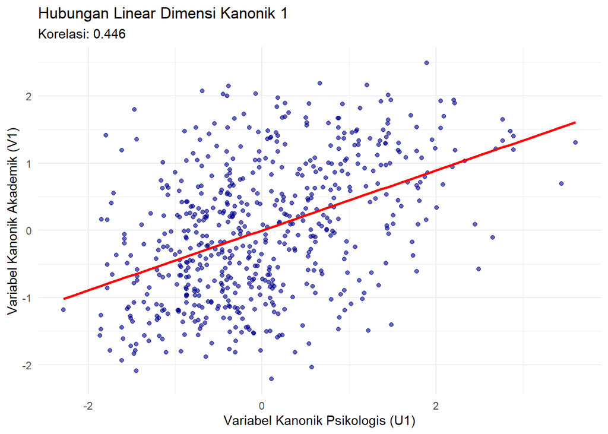

```r
# Membuat Data Frame untuk Plotting
scores_X <- data.frame(cca_fit$scores$xscores)
scores_Y <- data.frame(cca_fit$scores$yscores)
scores_df <- data.frame(scores_X, scores_Y)
colnames(scores_df) <- c("X_Can1", "X_Can2", "X_Can3",
                         "Y_Can1", "Y_Can2", "Y_Can3")

# Plot 1: Hubungan Variabel Kanonik Dimensi 1
p1 <- ggplot(scores_df, aes(x = X_Can1, y = Y_Can1)) +
  geom_point(alpha = 0.6, color = "darkblue") +
  geom_smooth(method = "lm", color = "red", se = FALSE) +
  labs(title = "Hubungan Linear Dimensi Kanonik 1",
       subtitle = paste("Korelasi:", round(cca_fit$cor[1], 3)),
       x = "Variabel Kanonik Psikologis (U1)",
       y = "Variabel Kanonik Akademik (V1)") +
  theme_minimal()
print(p1)
```

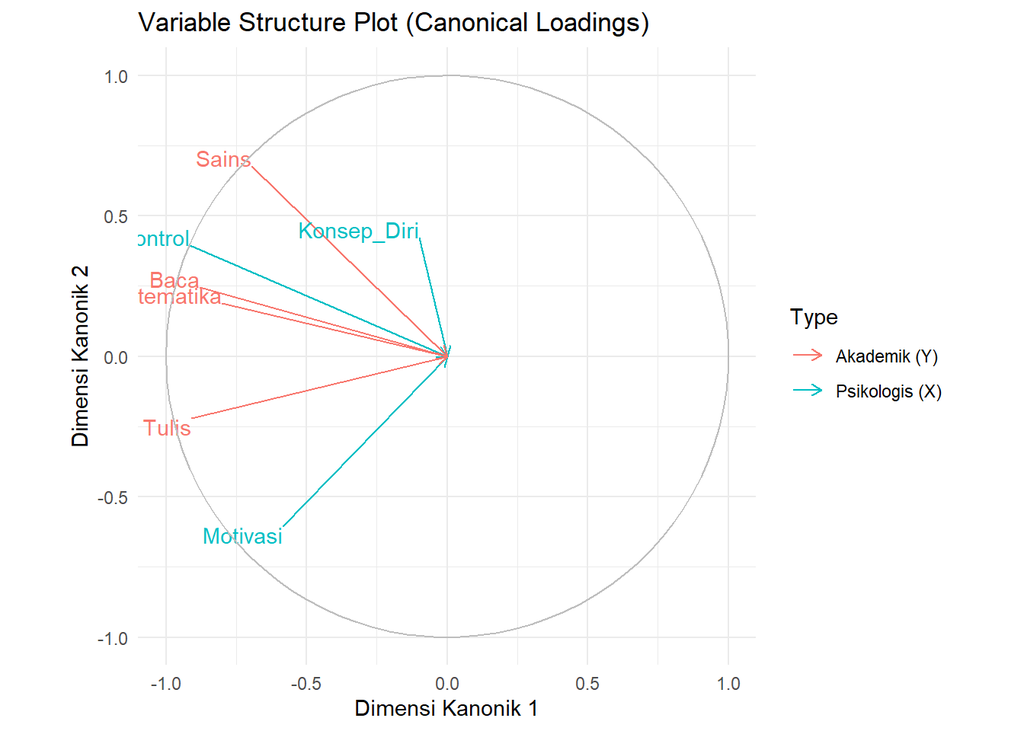

```r
# Plot 2: Helio Plot / Variable Structure Plot (Manual dengan ggplot)
# Ini menggantikan plt.cc agar lebih rapi dan informatif
# Menggabungkan loading X dan Y untuk Dimensi 1 dan 2
circle_data <- rbind(
  data.frame(Var = colnames(X),
             Dim1 = loadings$corr.X.xscores[,1],
             Dim2 = loadings$corr.X.xscores[,2],
             Type = "Psikologis (X)"),
  data.frame(Var = colnames(Y),
             Dim1 = loadings$corr.Y.yscores[,1],
             Dim2 = loadings$corr.Y.yscores[,2],
             Type = "Akademik (Y)")
)

# Menggambar Lingkaran Korelasi
p2 <- ggplot(circle_data, aes(x = Dim1, y = Dim2, color = Type, label = Var)) +
  geom_segment(aes(xend = 0, yend = 0), arrow = arrow(length = unit(0.2, "cm"))) +
  geom_text(vjust = "outward", hjust = "outward", show.legend = FALSE) +
  geom_path(data = data.frame(x = cos(seq(0, 2*pi, length.out=100)),
                              y = sin(seq(0, 2*pi, length.out=100))),
            aes(x=x, y=y), color="grey", inherit.aes = FALSE) +
  labs(title = "Variable Structure Plot (Canonical Loadings)",
       x = "Dimensi Kanonik 1", y = "Dimensi Kanonik 2") +
  coord_fixed() +
  theme_minimal()
print(p2)
```

Plot dimensi kanonik pertama menunjukkan adanya hubungan positif antara variabel kanonik psikologis dan akademik dengan nilai korelasi sebesar 0,446, yang mengindikasikan hubungan sedang. Pola sebaran titik yang mengikuti garis regresi positif menunjukkan bahwa peningkatan faktor psikologis cenderung diikuti oleh peningkatan kemampuan akademik.

# BAGIAN 9: RINGKASAN HASIL

```r
# ==============================================================================
# GENERATOR RINGKASAN HASIL OTOMATIS (Jalankan setelah analisis selesai)
# ==============================================================================

# 1. Persiapan Data untuk Laporan
cor_kanonik <- cca_fit$cor
n_sampel <- nrow(X)
vars_x_names <- colnames(X)
vars_y_names <- colnames(Y)

# Hitung Loadings lagi untuk pengambilan keputusan interpretasi
loadings <- comput(X_scale, Y_scale, cca_fit)
load_x <- loadings$corr.X.xscores[,1] # Loadings Dimensi 1
load_y <- loadings$corr.Y.yscores[,1] # Loadings Dimensi 1

# Cari variabel paling berpengaruh (Nilai loading absolut tertinggi)
top_x <- names(sort(abs(load_x), decreasing = TRUE)[1])
top_y <- names(sort(abs(load_y), decreasing = TRUE)[1])

# Uji Wilks
wilks_res <- p.asym(cca_fit$cor, n_sampel, ncol(X), ncol(Y), tstat = "Wilks")
```

```
## Wilks' Lambda, using F-approximation (Rao's F):
##               stat     approx df1      df2   p.value
## 1 to 3:  0.7814670 12.7735403  12 1569.222 0.0000000
## 2 to 3:  0.9759865  2.4210265   6 1188.000 0.0248771
## 3 to 3:  0.9994936  0.1507323   2  595.000 0.8601108
```

```r
p_val <- wilks_res$p.value[1] # P-value dimensi 1

# ==============================================================================
# CETAK LAPORAN (Output Teks)
# ==============================================================================

cat("\n=======================================================\n")
cat("               RINGKASAN HASIL ANALISIS CCA            \n")
```

```
##                RINGKASAN HASIL ANALISIS CCA
```

```r
cat("=======================================================\n\n")
cat("1. KASUS DAN DATA\n")
```

```
## 1. KASUS DAN DATA
```

```r
cat("-----------------\n")
cat("Analisis ini bertujuan melihat hubungan antara dua set variabel.\n")
```

```
## Analisis ini bertujuan melihat hubungan antara dua set variabel.
```

```r
cat("-> Set X (Independen):", paste(vars_x_names, collapse=", "), "\n")
```

```
## -> Set X (Independen): Locus_Control, Konsep_Diri, Motivasi
```

```r
cat("-> Set Y (Dependen)  :", paste(vars_y_names, collapse=", "), "\n")
```

```
## -> Set Y (Dependen)  : Baca, Tulis, Matematika, Sains
```

```r
cat("-> Jumlah Sampel     :", n_sampel, "observasi\n\n")
```

```
## -> Jumlah Sampel     : 600 observasi
```

```r
cat("2. OUTPUT ANALISIS UTAMA\n")
```

```
## 2. OUTPUT ANALISIS UTAMA
```

```r
cat("------------------------\n")
cat("A. Korelasi Kanonik (Kekuatan Hubungan):\n")
```

```
## A. Korelasi Kanonik (Kekuatan Hubungan):
```

```r
for(i in 1:length(cor_kanonik)){
  cat(sprintf("   - Dimensi %d: %.4f (Kuadrat korelasi: %.2f%%)\n",
              i, cor_kanonik[i], cor_kanonik[i]^2 * 100))
}
```

```
##    - Dimensi 1: 0.4464 (Kuadrat korelasi: 19.93%)
##    - Dimensi 2: 0.1534 (Kuadrat korelasi: 2.35%)
##    - Dimensi 3: 0.0225 (Kuadrat korelasi: 0.05%)
```

```r
cat("\nB. Canonical Loadings (Variabel Paling Berpengaruh di Dimensi 1):\n")
```

```
##
## B. Canonical Loadings (Variabel Paling Berpengaruh di Dimensi 1):
```

```r
cat("   [Set X]:\n")
```

```
##    [Set X]:
```

```r
print(round(load_x, 3))
```

```
## Locus_Control   Konsep_Diri      Motivasi
##        -0.914        -0.100        -0.585
```

```r
cat("   [Set Y]:\n")
```

```
##    [Set Y]:
```

```r
print(round(load_y, 3))
```

```
##       Baca      Tulis Matematika      Sains
##     -0.880     -0.910     -0.800     -0.694
```

```r
cat("\nC. Uji Signifikansi (Wilks' Lambda):\n")
```

```
##
## C. Uji Signifikansi (Wilks' Lambda):
```

```r
cat(sprintf("   - Nilai P-Value Dimensi 1: %.5f\n", p_val))
```

```
##    - Nilai P-Value Dimensi 1: 0.00000
```

```r
status_sig <- ifelse(p_val < 0.05, "SIGNIFIKAN (Tolak H0)", "TIDAK SIGNIFIKAN (Gagal Tolak H0)")
cat("   - Kesimpulan Statistik   :", status_sig, "\n\n")
```

```
##    - Kesimpulan Statistik   : SIGNIFIKAN (Tolak H0)
```

```r
cat("3. INTERPRETASI RINGKAS (Dimensi 1)\n")
```

```
## 3. INTERPRETASI RINGKAS (Dimensi 1)
```

```r
cat("-----------------------------------\n")
cat("Fungsi kanonik pertama menunjukkan korelasi sebesar", round(cor_kanonik[1], 3), ".\n")
```

```
## Fungsi kanonik pertama menunjukkan korelasi sebesar 0.446 .
```

```r
cat("Berdasarkan canonical loadings, variabel pembentuk utama adalah:\n")
```

```
## Berdasarkan canonical loadings, variabel pembentuk utama adalah:
```

```r
cat("-> Di sisi X:", top_x, "(Loading:", round(load_x[top_x],3), ")\n")
```

```
## -> Di sisi X: Locus_Control (Loading: -0.914 )
```

```r
cat("-> Di sisi Y:", top_y, "(Loading:", round(load_y[top_y],3), ")\n")
```

```
## -> Di sisi Y: Tulis (Loading: -0.91 )
```

```r
cat("Artinya, peningkatan pada", top_x, "cenderung diikuti oleh peningkatan/penurunan pada", top_y, ".\n\n")
```

```
## Artinya, peningkatan pada Locus_Control cenderung diikuti oleh peningkatan/penurunan pada Tulis .
```

```r
cat("4. KESIMPULAN SINGKAT\n")
```

```
## 4. KESIMPULAN SINGKAT
```

```r
cat("---------------------\n")
if(p_val < 0.05){
  cat("Terdapat bukti statistik yang cukup untuk menyatakan bahwa ada hubungan\n")
  cat("yang signifikan antara himpunan variabel X dan himpunan variabel Y.\n")
  cat("Hubungan ini paling kuat dijelaskan oleh pasangan variabel", top_x, "dan", top_y, ".")
} else {
  cat("Tidak terdapat bukti statistik yang cukup untuk menyatakan hubungan signifikan\n")
  cat("antara kedua himpunan variabel tersebut berdasarkan data ini.")
}
```

```
## Terdapat bukti statistik yang cukup untuk menyatakan bahwa ada hubungan
## yang signifikan antara himpunan variabel X dan himpunan variabel Y.
## Hubungan ini paling kuat dijelaskan oleh pasangan variabel Locus_Control dan Tulis .
```

```r
cat("\n\n=======================================================\n")
```

# BAGIAN 10: KESIMPULAN AKHIR